# Tutorial 1

Ashlesha Gogate

2023-07-27

TUTORIAL 1- VOLCANO PLOT

Load libraries

```r
library(ggplot2)
library(ggrepel)
```

Set working directory

```r
setwd("/Users/ashleshagogate/Documents/GT/ChahrourLab")
```

Read the data we will use for plotting

```r
df<- read.table(file="pseudobulk_allcells_kovswt.txt", header = TRUE, sep = "\t")
```

Lets see what the data looks like

```r
head(df)
```

```
##      gene     baseMean log2FoldChange     lfcSE       stat      pvalue
## 1    Xkr4 63439.014060    -0.09539091 0.2185978 -0.4363764 0.662563681
## 2  Gm1992   304.437393    -0.05274512 0.3463888 -0.1522714 0.878972864
## 3 Gm19938  2061.355744     0.34035554 0.3204126  1.0622413 0.288126166
## 4 Gm37381     3.867623     0.17293510 0.7220173  0.2395166 0.810705056
## 5     Rp1    90.490187     0.28377985 0.2195068  1.2928065 0.196078007
## 6   Sox17   183.857440     1.29873929 0.3903281  3.3273013 0.000876915
##         padj
## 1 0.90709277
## 2 0.97239864
## 3 0.70246843
## 4         NA
## 5 0.62497350
## 6 0.04384319
```

Basic scatter plot

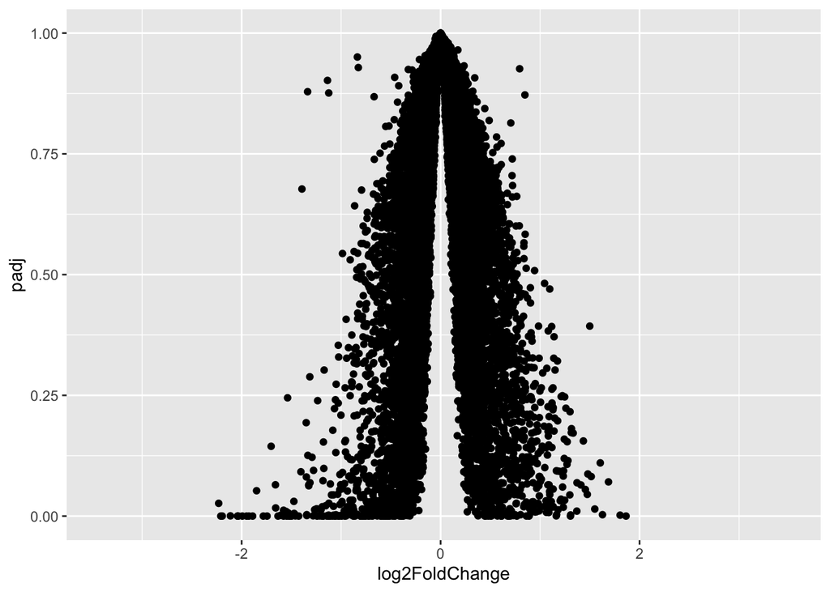

```r
ggplot(data=df,aes(x=log2FoldChange,y=padj))+geom_point()
```

Doesn’t look like a volcano plot. What is different?

Change y axis scale

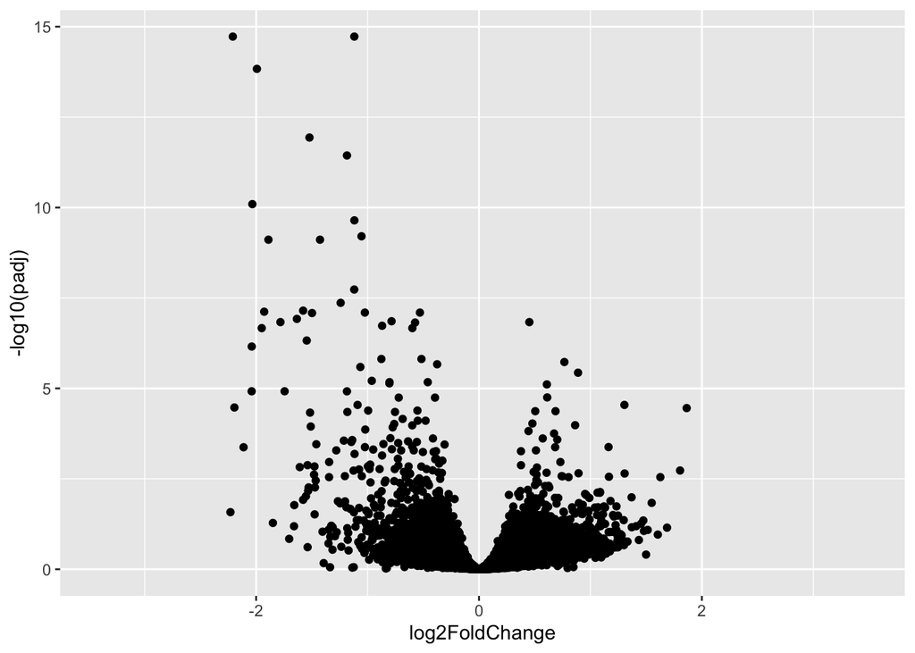

```r
ggplot(data=df, aes(x=log2FoldChange, y=-log10(padj))) + geom_point()
```

Lets get rid of the background grid lines

Add vertical lines that indicate log2FoldChange threshold and horizontal lines for padj threshold

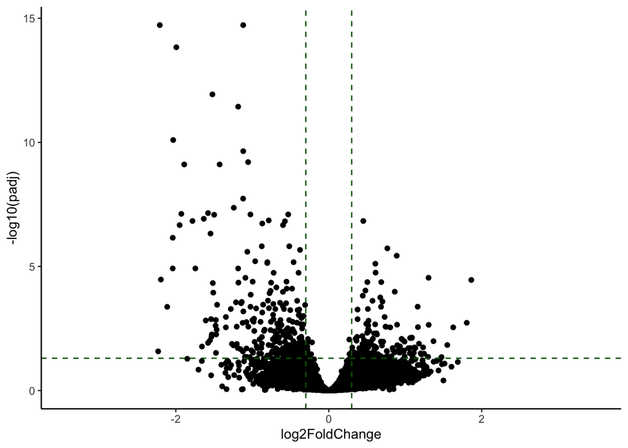

```r
ggplot(data=df, aes(x=log2FoldChange, y=-log10(padj))) + geom_point()+
  theme_classic()+
  geom_vline(xintercept=c(-0.3, 0.3), col="darkgreen",linetype=2) +
  geom_hline(yintercept=-log10(0.05), col="darkgreen",linetype=2)
```

Which genes are differentially expressed? The ones in the upper left and upper right corner

Add a column to the table to specify if a gene is differentially expressed

```r
df$Differential_Expression<-"No"
df$Differential_Expression[df$log2FoldChange>0.3 & df$padj<0.05 & df$pvalue<0.05]<-"Upregulated"
df$Differential_Expression[df$log2FoldChange< -0.3 & df$padj<0.05 & df$pvalue<0.05]<-"Downregulated"
```

Lets see the updated table

```r
head(df)
```

```
##      gene     baseMean log2FoldChange     lfcSE       stat      pvalue
## 1    Xkr4 63439.014060    -0.09539091 0.2185978 -0.4363764 0.662563681
## 2  Gm1992   304.437393    -0.05274512 0.3463888 -0.1522714 0.878972864
## 3 Gm19938  2061.355744     0.34035554 0.3204126  1.0622413 0.288126166
## 4 Gm37381     3.867623     0.17293510 0.7220173  0.2395166 0.810705056
## 5     Rp1    90.490187     0.28377985 0.2195068  1.2928065 0.196078007
## 6   Sox17   183.857440     1.29873929 0.3903281  3.3273013 0.000876915
##         padj Differential_Expression
## 1 0.90709277                      No
## 2 0.97239864                      No
## 3 0.70246843                      No
## 4         NA                      No
## 5 0.62497350                      No
## 6 0.04384319             Upregulated
```

Re-plot with “colour” parameter- this will colour the DEGs

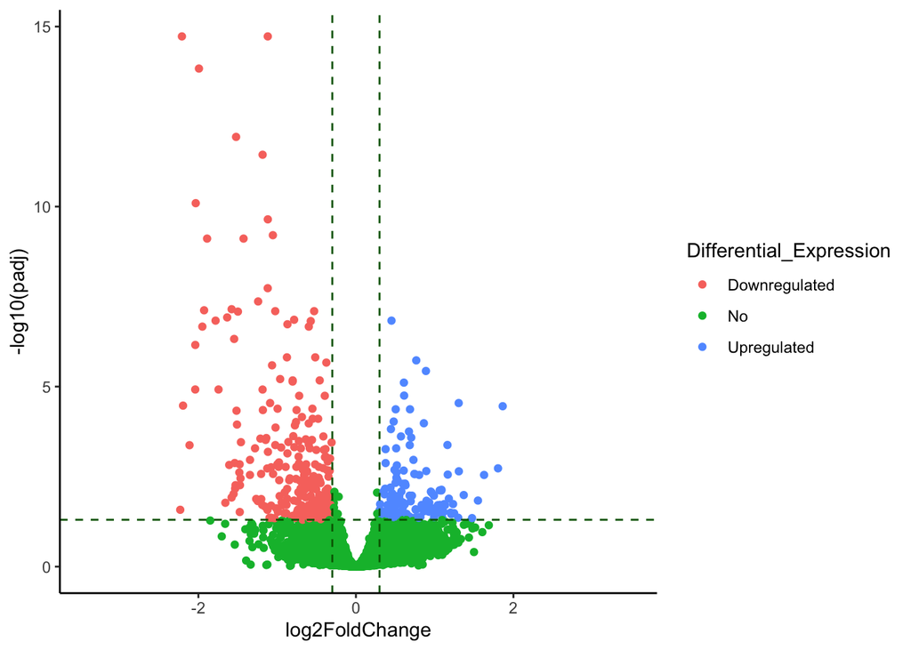

```r
ggplot(data=df, aes(x=log2FoldChange, y=-log10(padj), col=Differential_Expression)) + geom_point()+
  theme_classic()+
  geom_vline(xintercept=c(-0.3, 0.3), col="darkgreen",linetype=2) +
  geom_hline(yintercept=-log10(0.05), col="darkgreen",linetype=2)
```

Lets change these default colours and re-plot

Get rid of the “No” in the legend

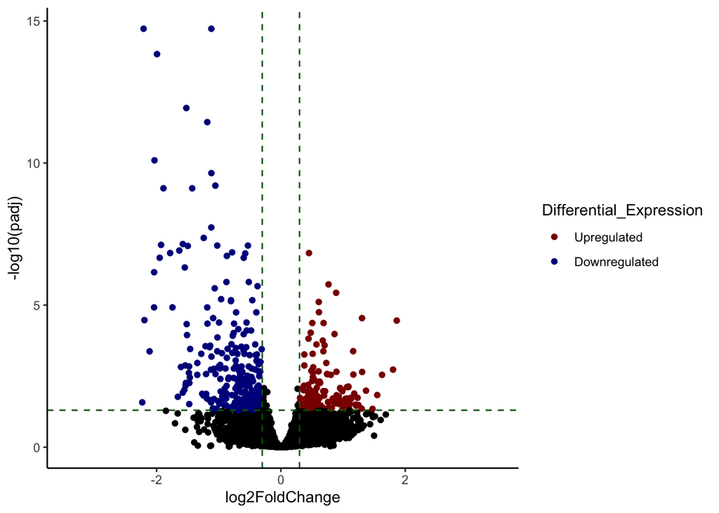

```r
mycolors <- c("black", "darkred","darkblue")
names(mycolors) <- c("No", "Upregulated","Downregulated")
ggplot(data=df, aes(x=log2FoldChange, y=-log10(padj), col=Differential_Expression)) + geom_point()+
  theme_classic()+
  geom_vline(xintercept=c(-0.3, 0.3), col="darkgreen",linetype=2) +
  geom_hline(yintercept=-log10(0.05), col="darkgreen",linetype=2) +
  scale_colour_manual(values = mycolors,breaks = c("Upregulated","Downregulated"))
```

Subset upregulated genes and order their log2FoldChange in descending order

```r
up<-df[df$Differential_Expression=="Upregulated",]
up<-up[order(up$log2FoldChange,decreasing = TRUE),]
head(up,10)
```

```
##                gene  baseMean log2FoldChange     lfcSE     stat       pvalue
## 4217          Sox18  62.24622       1.863729 0.3477190 5.359871 8.328160e-08
## 7189          Srarp  40.06249       1.804250 0.4106706 4.393425 1.115786e-05
## 22458         Foxq1 129.75330       1.627228 0.3813995 4.266466 1.985940e-05
## 22926        Ctla2a  85.83462       1.549738 0.4114951 3.766116 1.658067e-04
## 26242      AU021092  31.87635       1.474416 0.4449924 3.313352 9.218501e-04
## 3684            Id1 248.67660       1.369128 0.3522799 3.886477 1.017094e-04
## 3947           Pltp 421.29361       1.306853 0.3013894 4.336094 1.450368e-05
## 12102 2310002F09Rik 342.29414       1.304888 0.2413015 5.407708 6.383649e-08
## 6             Sox17 183.85744       1.298739 0.3903281 3.327301 8.769150e-04
## 25515          Ly6a 250.47139       1.247057 0.3611329 3.453181 5.540171e-04
##               padj Differential_Expression
## 4217  3.503379e-05             Upregulated
## 7189  1.861979e-03             Upregulated
## 22458 2.843979e-03             Upregulated
## 22926 1.461995e-02             Upregulated
## 26242 4.485301e-02             Upregulated
## 3684  1.026858e-02             Upregulated
## 3947  2.252757e-03             Upregulated
## 12102 2.864414e-05             Upregulated
## 6     4.384319e-02             Upregulated
## 25515 3.280561e-02             Upregulated
```

Subset downregulated genes and order their log2FoldChange in ascending order

```r
down<-df[df$Differential_Expression=="Downregulated",]
down<-down[order(down$log2FoldChange),]
head(down,10)
```

```
##                gene  baseMean log2FoldChange     lfcSE      stat       pvalue
## 13523       Gm36737  13.84861      -2.230672 0.6285622 -3.548848 3.869199e-04
## 12613       Gm39043  89.59961      -2.209359 0.2438352 -9.060868 1.294167e-19
## 13205        Gpr139 110.70815      -2.194958 0.4087084 -5.370475 7.852954e-08
## 23481          Isl1  59.84630      -2.112778 0.4423241 -4.776537 1.783395e-06
## 22132       Gm40663  52.83201      -2.040160 0.3655100 -5.581679 2.382077e-08
## 15977          Drd2 576.46235      -2.039419 0.3331976 -6.120749 9.313668e-10
## 28523          Six3 175.28361      -2.034008 0.2666643 -7.627595 2.391726e-14
## 17748       Adora2a 514.22889      -1.993119 0.2278516 -8.747445 2.182383e-18
## 19101 9230009I02Rik  44.09809      -1.949885 0.3086856 -6.316735 2.671462e-10
## 28522       Six3os1  62.48599      -1.927602 0.2936969 -6.563237 5.265214e-11
##               padj Differential_Expression
## 13523 2.639421e-02           Downregulated
## 12613 1.878215e-15           Downregulated
## 13205 3.373763e-05           Downregulated
## 23481 4.236508e-04           Downregulated
## 22132 1.202472e-05           Downregulated
## 15977 6.965244e-07           Downregulated
## 28523 8.048956e-11           Downregulated
## 17748 1.468889e-14           Downregulated
## 19101 2.157687e-07           Downregulated
## 28522 7.593943e-08           Downregulated
```

Lets make a list of the top 10 upregulated genes and top 10 downregulated genes

```r
top_genes<-append((up[1:10,1]),(down[1:10,1]))
```

instead of this, you can also label specific genes of your choice by making a list of gene names like you did for colors.

Write the names of these top DEGs next to their point

```r
df$delabel<-NA
```

Check if the value in the gene column exists in the top_genes list

If it does, change the NA label to the gene name

```r
df$delabel[df$gene %in% top_genes]<-df$gene[df$gene %in% top_genes]
```

Lets look at the updated table

```r
head(df)
```

```
##      gene     baseMean log2FoldChange     lfcSE       stat      pvalue
## 1    Xkr4 63439.014060    -0.09539091 0.2185978 -0.4363764 0.662563681
## 2  Gm1992   304.437393    -0.05274512 0.3463888 -0.1522714 0.878972864
## 3 Gm19938  2061.355744     0.34035554 0.3204126  1.0622413 0.288126166
## 4 Gm37381     3.867623     0.17293510 0.7220173  0.2395166 0.810705056
## 5     Rp1    90.490187     0.28377985 0.2195068  1.2928065 0.196078007
## 6   Sox17   183.857440     1.29873929 0.3903281  3.3273013 0.000876915
##         padj Differential_Expression delabel
## 1 0.90709277                      No    <NA>
## 2 0.97239864                      No    <NA>
## 3 0.70246843                      No    <NA>
## 4         NA                      No    <NA>
## 5 0.62497350                      No    <NA>
## 6 0.04384319             Upregulated   Sox17
```

Plot with labels

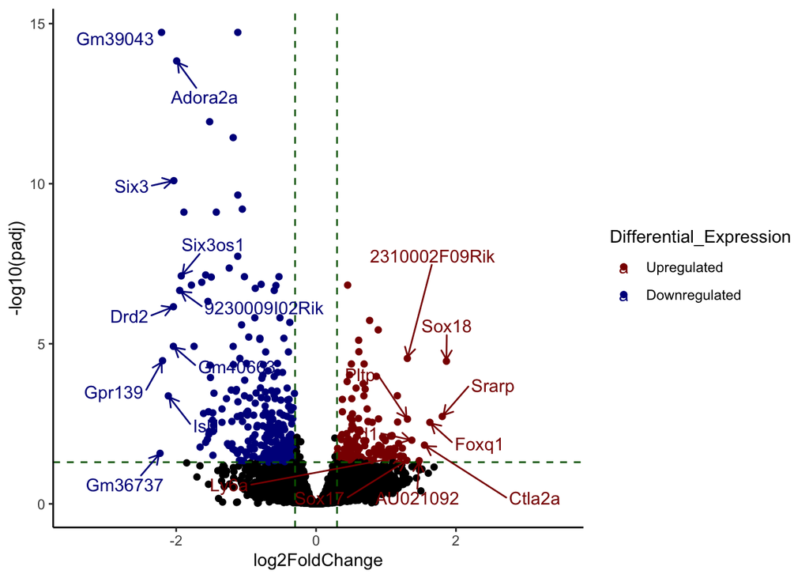

```r
ggplot(data=df, aes(x=log2FoldChange, y=-log10(padj), col=Differential_Expression, label=delabel)) + geom_point()+
  theme_classic()+
  geom_vline(xintercept=c(-0.3, 0.3), col="darkgreen",linetype=2) +
  geom_hline(yintercept=-log10(0.05), col="darkgreen",linetype=2) +
  scale_colour_manual(values = mycolors,breaks = c("Upregulated","Downregulated")) +
  geom_text_repel(arrow = arrow(length = unit(0.02, "npc")),box.padding = 1,max.overlaps=Inf)
```

Change titles and clean up

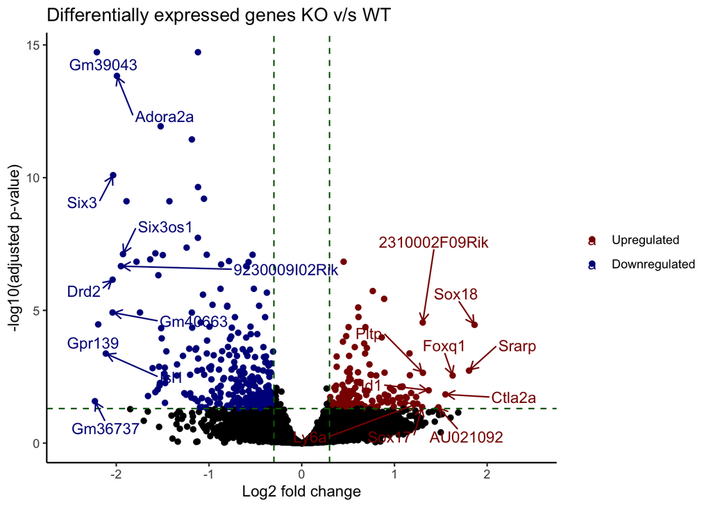

```r
ggplot(data=df, aes(x=log2FoldChange, y=-log10(padj), col=Differential_Expression, label=delabel)) + geom_point()+
  theme_classic()+
  geom_vline(xintercept=c(-0.3, 0.3), col="darkgreen",linetype=2) +
  geom_hline(yintercept=-log10(0.05), col="darkgreen",linetype=2) +
  scale_colour_manual(values = mycolors,breaks = c("Upregulated","Downregulated")) +
  geom_text_repel(arrow = arrow(length = unit(0.02, "npc")),box.padding = 1,max.overlaps=Inf) +
  xlim(-2.5,2.5)+
  xlab("Log2 fold change")+
  ylab("-log10(adjusted p-value)")+
  ggtitle("Differentially expressed genes KO v/s WT")+
  theme(legend.title=element_blank())
```

Save the plot

```r
p<- ggplot(data=df, aes(x=log2FoldChange, y=-log10(padj), col=Differential_Expression, label=delabel)) + geom_point()+
  theme_classic()+
  geom_vline(xintercept=c(-0.3, 0.3), col="darkgreen",linetype=2) +
  geom_hline(yintercept=-log10(0.05), col="darkgreen",linetype=2) +
  scale_colour_manual(values = mycolors,breaks = c("Upregulated","Downregulated")) +
  geom_text_repel(arrow = arrow(length = unit(0.02, "npc")),box.padding = 1,max.overlaps=Inf) +
  xlim(-2.5,2.5)+
  xlab("Log2 fold change")+
  ylab("-log10(adjusted p-value)")+
  ggtitle("Differentially expressed genes KO v/s WT")+
  theme(legend.title=element_blank())

png(file="volcano_plot.png",width=800,height=800,res=100)
print(p)
dev.off()
```

CHALLENGE 1 - MA PLOT

Define the genes to be labelled and add them to the table

```r
top_genes<-c("Sox18","Foxq1","Isl1","Drd2")
df$delabel<-NA
df$delabel[df$gene %in% top_genes]<-df$gene[df$gene %in% top_genes]
```

Plot the MA plot

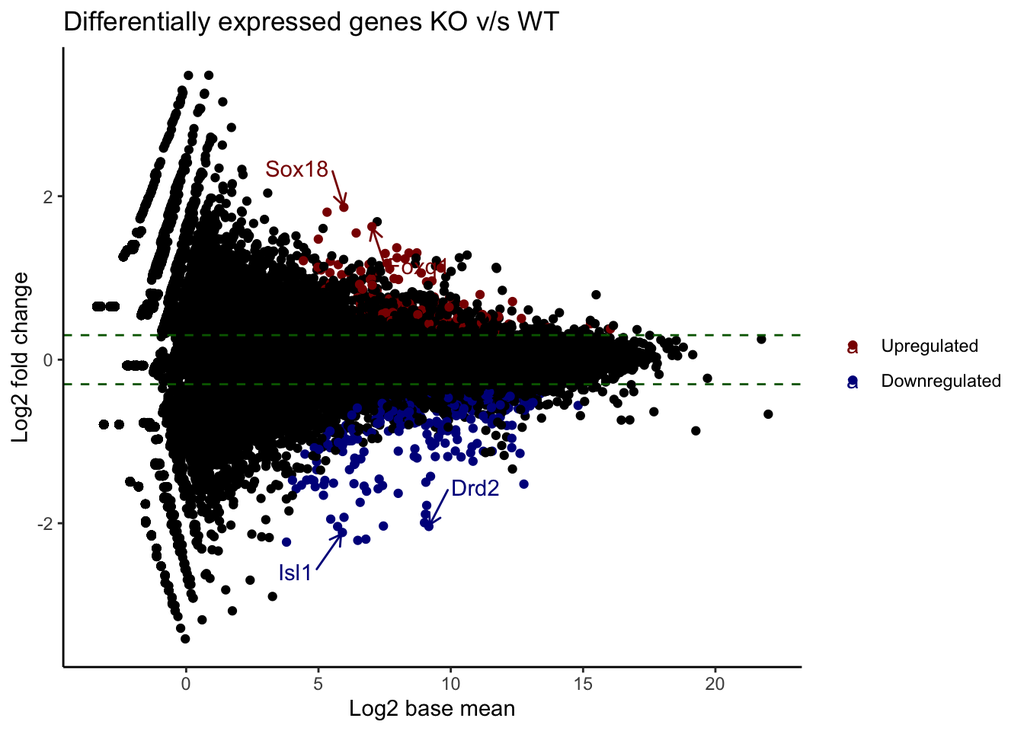

```r
q<- ggplot(data=df, aes(x=log2(baseMean), y=log2FoldChange, col=Differential_Expression, label=delabel)) + geom_point()+
  theme_classic()+
  geom_hline(yintercept=c(-0.3, 0.3), col="darkgreen",linetype=2) +
  scale_colour_manual(values = mycolors,breaks = c("Upregulated","Downregulated")) +
  geom_text_repel(arrow = arrow(length = unit(0.02, "npc")),box.padding = 1,max.overlaps=Inf)+
  xlab("Log2 base mean")+
  ylab("Log2 fold change")+
  ggtitle("Differentially expressed genes KO v/s WT")+
  theme(legend.title=element_blank())
q
```

Save the plot

```r
png(file="ma_plot.png",width=800,height=800,res=100)
print(q)
dev.off()
```